# Homework 3 - ZOMBIES

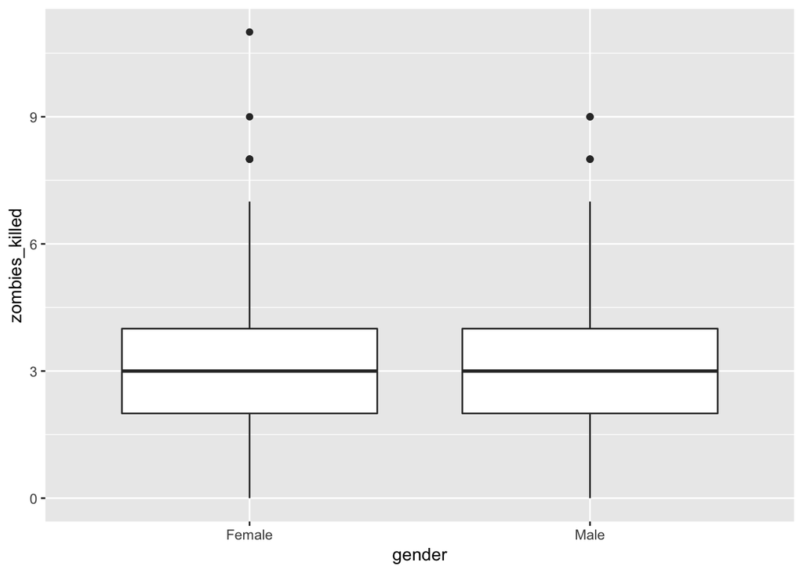

```r
z
```

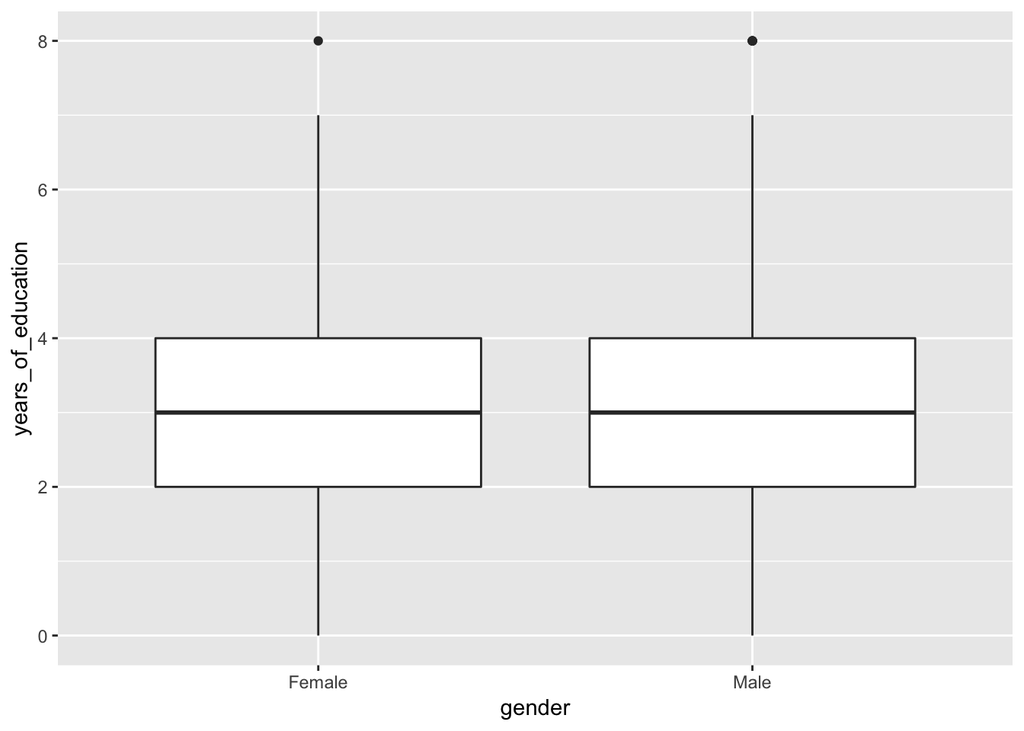

```r
e
```

So the genders really only differ in height and weight.

3. Use {ggplot} to make scatterplots of height and weight in relation to age. Do these variables seem to be related? In what way?

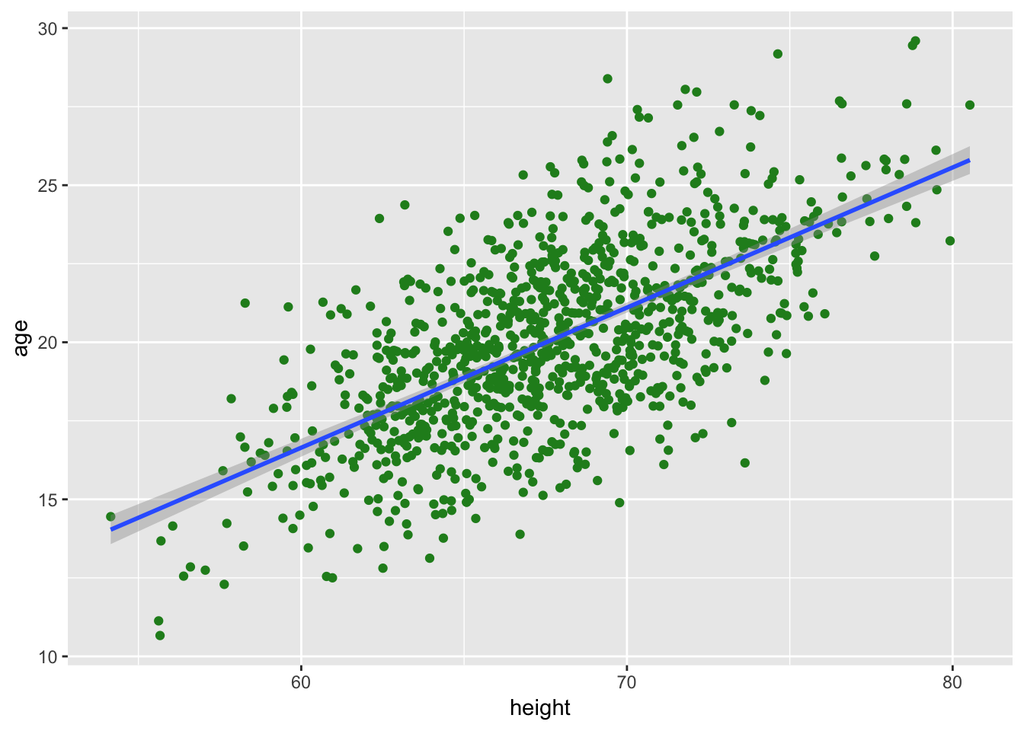

```r
g <- ggplot(data = s, aes(x = height, y = age))
g <- g + geom_point(color="forestgreen")
g <- g + geom_smooth(method = "lm", formula = y ~ x)
g
```

And for weight and age:

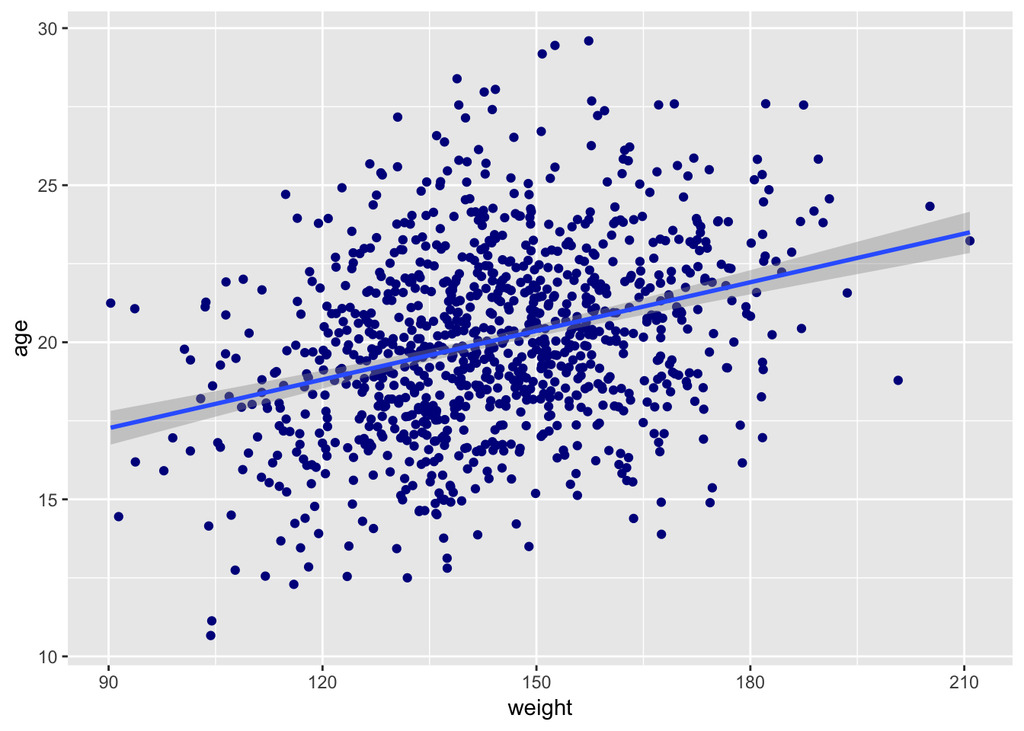

```r
g <- ggplot(data = s, aes(x = weight, y = age))
g <- g + geom_point(color="darkblue")
g <- g + geom_smooth(method = "lm", formula = y ~ x)
g
```

As we could predict, it does seem as though both height and weight increase with the person’s age. However, that correlation seems to be tighter when relating height and age, while weight and age are correlated, but has more deviation within the data and is less positively correlated. The confidence intervals (in gray) are less tight.

4. Using histograms and Q-Q plots, check whether the quantitative variables seem to be drawn from a normal distribution. Which seem to be and which do not (hint: not all are drawn from the normal distribution)? For those that are not normal, can you determine from which common distribution they are drawn?

Lets check the distribution through histograms first:

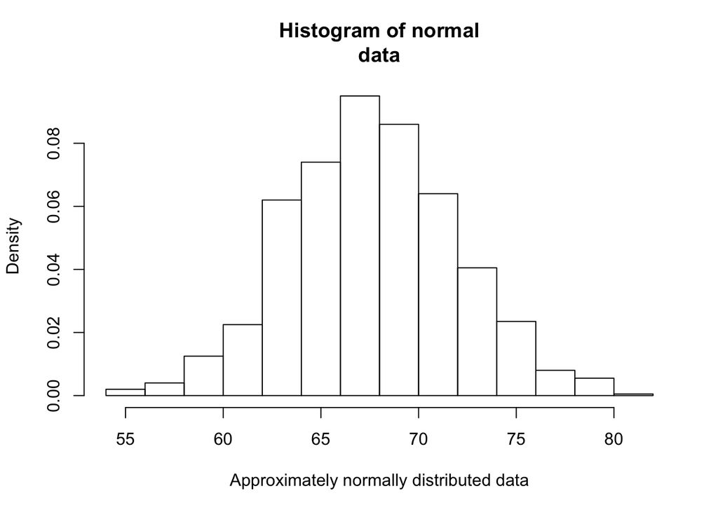

```r
hist(s$height,probability=TRUE, main="Histogram of normal
data",xlab="Approximately normally distributed data")
```

So far this looks about right, seeing as the tallest bar is about where the mean should be. Now I’ll do the same for the other variables:

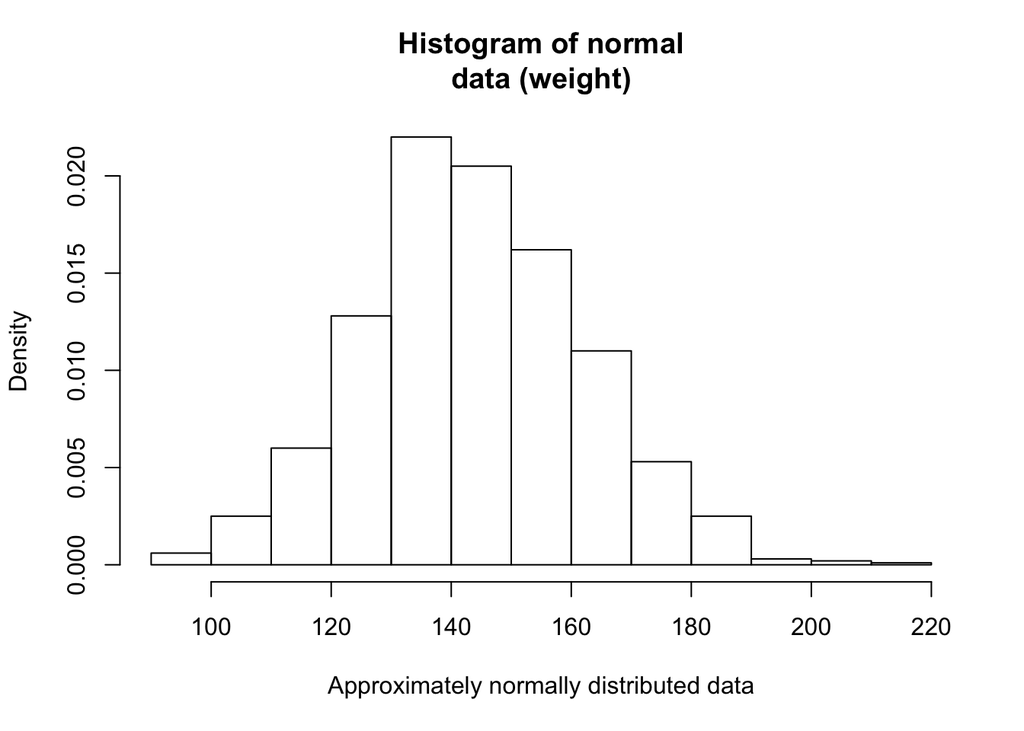

```r
hist(s$weight,probability=TRUE, main="Histogram of normal
data (weight)",xlab="Approximately normally distributed data")
```

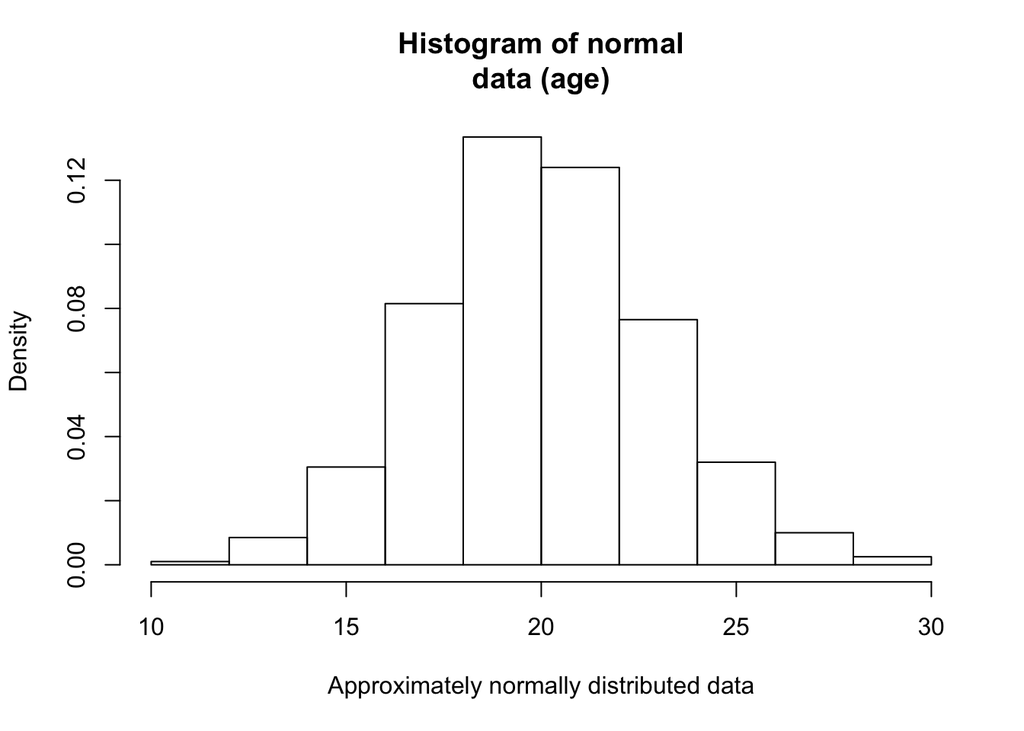

```r
hist(s$age,probability=TRUE, main="Histogram of normal
data (age)",xlab="Approximately normally distributed data")
```

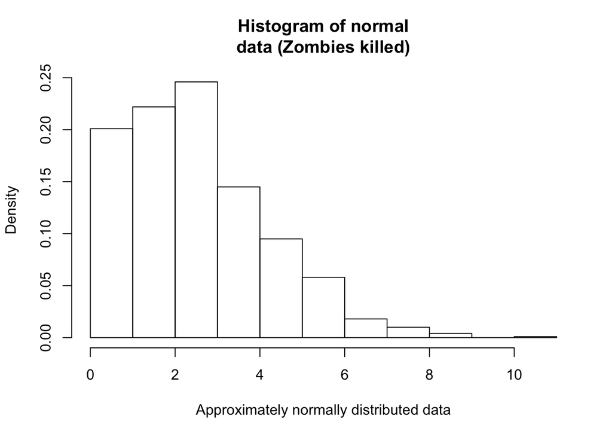

```r
hist(s$zombies_killed,probability=TRUE, main="Histogram of normal
data (Zombies killed)",xlab="Approximately normally distributed data")
```

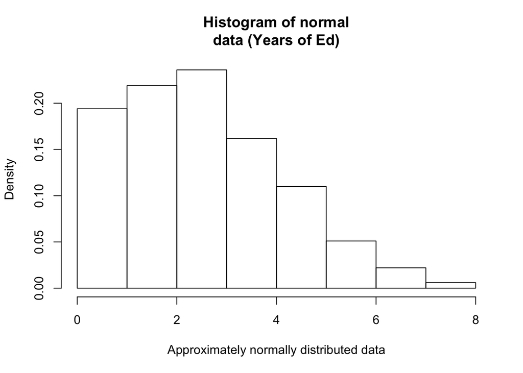

```r
hist(s$years_of_education,probability=TRUE, main="Histogram of normal
data (Years of Ed)",xlab="Approximately normally distributed data")
```

As far as the histograms go, it looks like all variables are normally distributed about the mean except for the years of education and number of zombies killed. Now let’s try the Q-Q plots.

First I am going to look at those three that seem normally distributed:

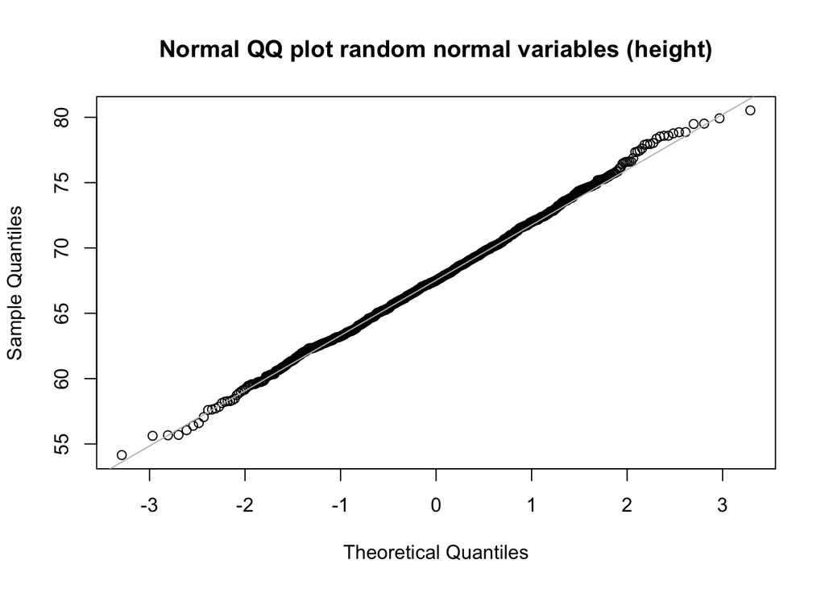

```r
qqnorm(s$height,main="Normal QQ plot random normal variables (height)")
qqline(s$height,col="gray")
```

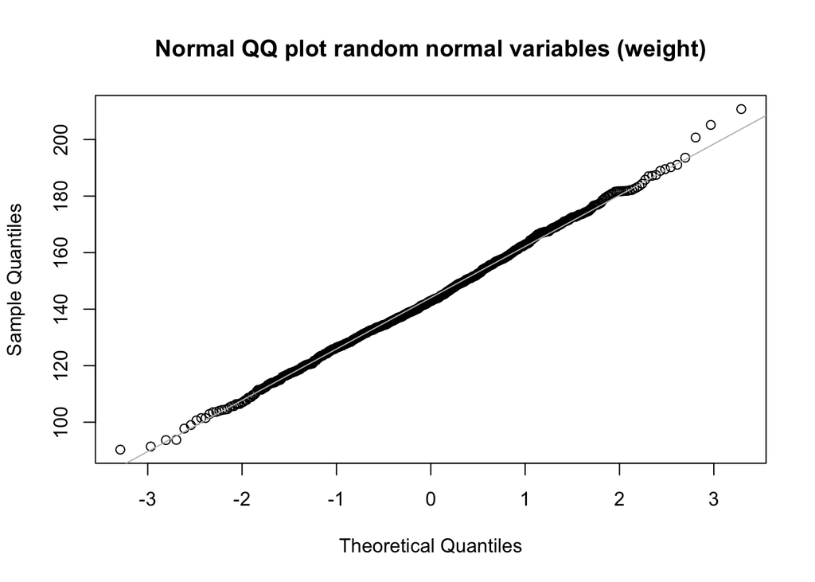

```r
qqnorm(s$weight,main="Normal QQ plot random normal variables (weight)")
qqline(s$weight,col="gray")
```

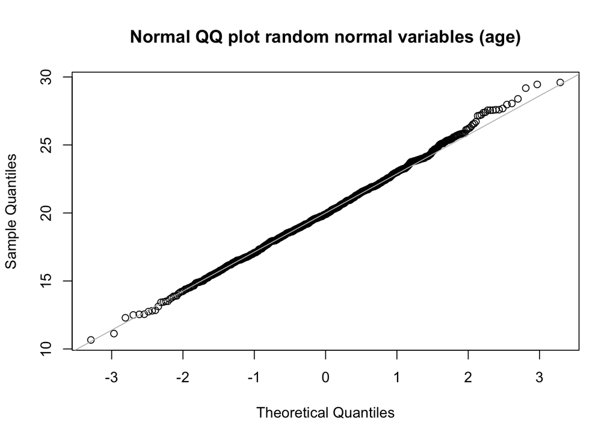

```r
qqnorm(s$age,main="Normal QQ plot random normal variables (age)")
qqline(s$age,col="gray")
```

All the dots are either on or pretty close to the line, so seems pretty normal!